# Turn Taking Distributional Analyses

# 1 Experiment 1

In this study, children and adults answered questions while playing an iPad game. We varied

- Whether the questions’s final word was predicted or not (factor Pred/Unpred).
- Whether the context of the question meant that the length of the final word was predictable or not (factor Match/Mismatcb).
- The interaction of these two factors (i.e., a proper test of whether participants predict during conversation).

In this analysis, we fit hierarchical Bayesian models to characterize the distribution of reaction times, assuming that they follow an ex-gaussian. All models are fit using the package *brms*.

## 1.1 Distribution of Response Times

The graphs below show the distribution of normaliszed RTs across conditions. When the answer was less predictable, participants were slower to respond. But there was no interaction in the non-distributional analyses.

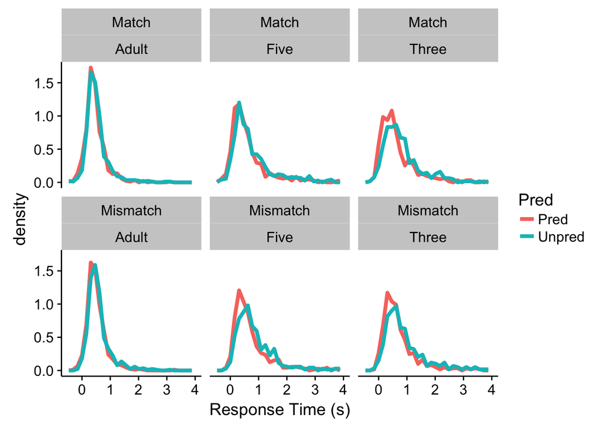

## 1.2 Analysis

An ex-gaussian distribution convolves a normal distribution with an exponential – this gives it a long and heavy right tail. We aimed to fit an ex-Gaussian to the response time data, comparing adults with children, and hierarchically modeling the mu parameter, the sigma parameter, and the tau parameter. Mu is the mean of the normal and sigma its standard deviation, while tau is the rate of the exponential. We modeled how these varied across conditions, accounting for random subjec intercepts. We print the structure of each model below.

Note that Tau is called Beta in the model, as per brms convention.

### 1.2.1 Ex-Gaussian analysis of All ages

#### 1.2.1.1 All age groups model

```r
 z <- 1
 convert_stan_to_dataframe <- function(stan_object){
   sum.df <- data.frame(summary(stan_object)$fixed)
   sum.df$Diff_from_zero <- ifelse((sum.df$l.95..CI * sum.df$u.95..CI) > 0, "*","-")
   return(sum.df)
 }

formula(expt1.fullage)
```

```
## rt ~ 1 + Age * Match * Pred + (1 | Subject) + (1 | Time.to.Say.Character.Name)
## beta ~ 1 + Age * Match * Pred + (1 | Subject) + (1 | Time.to.Say.Character.Name)
## sigma ~ 1 + Age * Match * Pred + (1 | Subject) + (1 | Time.to.Say.Character.Name)
```

```r
expt1.full.summary <- convert_stan_to_dataframe(expt1.fullage)


kable(expt1.full.summary, digits = 2)
```

|  | Estimate | Est.Error | l.95..CI | u.95..CI | Eff.Sample | Rhat | Diff_from_zero |
| --- | --- | --- | --- | --- | --- | --- | --- |
| Intercept | 1.10 | 0.04 | 1.02 | 1.18 | 399.94 | 1.01 | * |
| sigma_Intercept | -2.07 | 0.11 | -2.30 | -1.86 | 1295.10 | 1.00 | * |
| beta_Intercept | -1.65 | 0.14 | -1.93 | -1.38 | 580.34 | 1.00 | * |
| AgeFive | -0.17 | 0.05 | -0.28 | -0.06 | 520.18 | 1.01 | * |
| AgeThree | -0.17 | 0.05 | -0.28 | -0.06 | 575.98 | 1.00 | * |
| MatchMismatch | 0.01 | 0.02 | -0.02 | 0.04 | 1491.13 | 1.00 | - |
| PredUnpred | 0.04 | 0.02 | 0.00 | 0.07 | 1445.95 | 1.00 | * |
| AgeFive:MatchMismatch | 0.00 | 0.03 | -0.06 | 0.06 | 1772.46 | 1.00 | - |
| AgeThree:MatchMismatch | 0.04 | 0.03 | -0.02 | 0.10 | 2171.02 | 1.00 | - |
| AgeFive:PredUnpred | 0.01 | 0.03 | -0.04 | 0.07 | 1983.56 | 1.00 | - |
| AgeThree:PredUnpred | 0.07 | 0.04 | 0.00 | 0.15 | 2222.78 | 1.00 | - |
| MatchMismatch:PredUnpred | -0.05 | 0.02 | -0.09 | 0.00 | 1259.86 | 1.00 | * |
| AgeFive:MatchMismatch:PredUnpred | 0.06 | 0.04 | -0.02 | 0.15 | 1786.32 | 1.00 | - |
| AgeThree:MatchMismatch:PredUnpred | -0.01 | 0.05 | -0.11 | 0.09 | 1815.12 | 1.00 | - |
| sigma_AgeFive | 0.08 | 0.17 | -0.26 | 0.40 | 1902.41 | 1.00 | - |
| sigma_AgeThree | -0.02 | 0.19 | -0.39 | 0.34 | 1966.18 | 1.00 | - |
| sigma_MatchMismatch | -0.11 | 0.10 | -0.31 | 0.10 | 1671.85 | 1.00 | - |
| sigma_PredUnpred | -0.10 | 0.12 | -0.34 | 0.13 | 1722.60 | 1.00 | - |
| sigma_AgeFive:MatchMismatch | 0.03 | 0.19 | -0.34 | 0.41 | 3200.00 | 1.00 | - |
| sigma_AgeThree:MatchMismatch | 0.10 | 0.21 | -0.32 | 0.51 | 1968.91 | 1.00 | - |
| sigma_AgeFive:PredUnpred | 0.02 | 0.19 | -0.36 | 0.40 | 2394.13 | 1.00 | - |
| sigma_AgeThree:PredUnpred | 0.19 | 0.24 | -0.30 | 0.66 | 2030.69 | 1.00 | - |
| sigma_MatchMismatch:PredUnpred | -0.07 | 0.17 | -0.39 | 0.25 | 1557.22 | 1.00 | - |
| sigma_AgeFive:MatchMismatch:PredUnpred | 0.26 | 0.30 | -0.33 | 0.83 | 2095.08 | 1.00 | - |
| sigma_AgeThree:MatchMismatch:PredUnpred | 0.11 | 0.33 | -0.53 | 0.78 | 1765.01 | 1.00 | - |
| beta_AgeFive | 1.12 | 0.17 | 0.80 | 1.46 | 1048.13 | 1.00 | * |
| beta_AgeThree | 1.19 | 0.17 | 0.86 | 1.51 | 741.15 | 1.00 | * |
| beta_MatchMismatch | -0.07 | 0.10 | -0.28 | 0.12 | 1339.73 | 1.00 | - |
| beta_PredUnpred | 0.19 | 0.11 | -0.01 | 0.40 | 1374.57 | 1.00 | - |
| beta_AgeFive:MatchMismatch | 0.09 | 0.13 | -0.17 | 0.35 | 1438.22 | 1.00 | - |
| beta_AgeThree:MatchMismatch | -0.05 | 0.13 | -0.32 | 0.21 | 1516.39 | 1.00 | - |
| beta_AgeFive:PredUnpred | -0.09 | 0.13 | -0.35 | 0.16 | 1592.00 | 1.00 | - |
| beta_AgeThree:PredUnpred | -0.11 | 0.14 | -0.40 | 0.16 | 1643.78 | 1.00 | - |
| beta_MatchMismatch:PredUnpred | 0.21 | 0.13 | -0.05 | 0.48 | 1130.71 | 1.00 | - |
| beta_AgeFive:MatchMismatch:PredUnpred | -0.16 | 0.17 | -0.51 | 0.19 | 1399.77 | 1.00 | - |
| beta_AgeThree:MatchMismatch:PredUnpred | 0.01 | 0.19 | -0.35 | 0.39 | 1359.47 | 1.00 | - |

#### 1.2.1.2 Adults alone model

```r
 z <- 1

expt1.fine.adults.summary <- convert_stan_to_dataframe(expt1.fullage.adult)
formula(expt1.fullage.adult)
```

```
## rt ~ 1 + Match * Pred + (1 | Subject) + (1 | Time.to.Say.Character.Name)
## beta ~ 1 + Match * Pred + (1 | Subject) + (1 | Time.to.Say.Character.Name)
## sigma ~ 1 + Match * Pred + (1 | Subject) + (1 | Time.to.Say.Character.Name)
```

```r
kable(expt1.fine.adults.summary, digits = 2)
```

|  | Estimate | Est.Error | l.95..CI | u.95..CI | Eff.Sample | Rhat | Diff_from_zero |
| --- | --- | --- | --- | --- | --- | --- | --- |
| Intercept | 1.10 | 0.06 | 0.99 | 1.22 | 245.61 | 1.02 | * |
| sigma_Intercept | -2.11 | 0.12 | -2.35 | -1.87 | 825.61 | 1.01 | * |
| beta_Intercept | -1.67 | 0.16 | -1.98 | -1.37 | 453.99 | 1.01 | * |
| MatchMismatch | 0.04 | 0.02 | 0.01 | 0.07 | 1022.29 | 1.01 | * |
| PredUnpred | 0.05 | 0.02 | 0.02 | 0.09 | 1006.15 | 1.01 | * |
| MatchMismatch:PredUnpred | -0.06 | 0.02 | -0.11 | -0.01 | 954.81 | 1.01 | * |
| sigma_MatchMismatch | -0.07 | 0.11 | -0.28 | 0.13 | 1332.82 | 1.00 | - |
| sigma_PredUnpred | -0.08 | 0.11 | -0.30 | 0.15 | 1299.46 | 1.00 | - |
| sigma_MatchMismatch:PredUnpred | -0.12 | 0.16 | -0.44 | 0.20 | 1211.66 | 1.00 | - |
| beta_MatchMismatch | -0.12 | 0.11 | -0.33 | 0.09 | 1066.73 | 1.01 | - |
| beta_PredUnpred | 0.15 | 0.11 | -0.06 | 0.38 | 1164.26 | 1.00 | - |
| beta_MatchMismatch:PredUnpred | 0.26 | 0.14 | -0.02 | 0.53 | 1081.80 | 1.00 | - |

#### 1.2.1.3 Fives alone model

```r
 z <- 1

expt1.fine.five.summary <- convert_stan_to_dataframe(expt1.fullage.five)
formula(expt1.fullage.five)
```

```
## rt ~ 1 + Match * Pred + (1 | Subject) + (1 | Time.to.Say.Character.Name)
## beta ~ 1 + Match * Pred + (1 | Subject) + (1 | Time.to.Say.Character.Name)
## sigma ~ 1 + Match * Pred + (1 | Subject) + (1 | Time.to.Say.Character.Name)
```

```r
kable(expt1.fine.five.summary, digits = 2)
```

|  | Estimate | Est.Error | l.95..CI | u.95..CI | Eff.Sample | Rhat | Diff_from_zero |
| --- | --- | --- | --- | --- | --- | --- | --- |
| Intercept | 0.96 | 0.04 | 0.88 | 1.04 | 759.17 | 1.00 | * |
| sigma_Intercept | -1.97 | 0.14 | -2.28 | -1.70 | 2043.16 | 1.00 | * |
| beta_Intercept | -0.57 | 0.14 | -0.86 | -0.29 | 631.72 | 1.01 | * |
| MatchMismatch | -0.05 | 0.03 | -0.10 | 0.01 | 1670.75 | 1.00 | - |
| PredUnpred | 0.02 | 0.03 | -0.05 | 0.09 | 1328.43 | 1.00 | - |
| MatchMismatch:PredUnpred | 0.07 | 0.05 | -0.02 | 0.16 | 1305.49 | 1.00 | - |
| sigma_MatchMismatch | -0.16 | 0.18 | -0.52 | 0.20 | 2077.65 | 1.00 | - |
| sigma_PredUnpred | -0.15 | 0.20 | -0.55 | 0.23 | 1889.48 | 1.00 | - |
| sigma_MatchMismatch:PredUnpred | 0.38 | 0.27 | -0.15 | 0.93 | 1686.13 | 1.00 | - |
| beta_MatchMismatch | 0.10 | 0.09 | -0.08 | 0.28 | 1666.19 | 1.00 | - |
| beta_PredUnpred | 0.19 | 0.11 | -0.01 | 0.40 | 1553.10 | 1.00 | - |
| beta_MatchMismatch:PredUnpred | -0.06 | 0.13 | -0.33 | 0.20 | 1411.35 | 1.00 | - |

```r
 z <- 1

expt1.fine.three.summary <- convert_stan_to_dataframe(expt1.fullage.three)
formula(expt1.fullage.three)
```

```
## rt ~ 1 + Match * Pred + (1 | Subject) + (1 | Time.to.Say.Character.Name)
## beta ~ 1 + Match * Pred + (1 | Subject) + (1 | Time.to.Say.Character.Name)
## sigma ~ 1 + Match * Pred + (1 | Subject) + (1 | Time.to.Say.Character.Name)
```

```r
kable(expt1.fine.three.summary, digits = 2)
```

|  | Estimate | Est.Error | l.95..CI | u.95..CI | Eff.Sample | Rhat | Diff_from_zero |
| --- | --- | --- | --- | --- | --- | --- | --- |
| Intercept | 0.95 | 0.05 | 0.85 | 1.04 | 438.40 | 1.01 | * |
| sigma_Intercept | -2.50 | 0.27 | -3.11 | -2.03 | 666.05 | 1.01 | * |
| beta_Intercept | -0.43 | 0.10 | -0.63 | -0.22 | 929.02 | 1.00 | * |
| MatchMismatch | -0.01 | 0.03 | -0.07 | 0.05 | 1052.33 | 1.00 | - |
| PredUnpred | 0.12 | 0.04 | 0.04 | 0.21 | 793.72 | 1.00 | * |
| MatchMismatch:PredUnpred | -0.06 | 0.05 | -0.16 | 0.04 | 812.91 | 1.00 | - |
| sigma_MatchMismatch | -0.12 | 0.35 | -0.86 | 0.53 | 1055.43 | 1.00 | - |
| sigma_PredUnpred | 0.21 | 0.35 | -0.46 | 0.89 | 1036.18 | 1.00 | - |
| sigma_MatchMismatch:PredUnpred | 0.23 | 0.46 | -0.61 | 1.15 | 1058.11 | 1.00 | - |
| beta_MatchMismatch | -0.07 | 0.09 | -0.26 | 0.11 | 1186.62 | 1.01 | - |
| beta_PredUnpred | 0.02 | 0.11 | -0.21 | 0.24 | 1189.02 | 1.00 | - |
| beta_MatchMismatch:PredUnpred | 0.27 | 0.14 | -0.01 | 0.56 | 1109.22 | 1.00 | - |

### 1.2.2 Ex Gaussian analysis of Adults versus kids with random effects

Note that these models **include random effects**.

#### 1.2.2.1 Full model

```r
load("expt1_brms_1sd.RDATA")
z<-1
expt1.gross.summary <- convert_stan_to_dataframe(expt1.grossage)
formula(expt1.grossage)
```

```
## rt ~ 1 + Age * Match * Pred + (1 + Match * Pred | Subject) + (1 | Time.to.Say.Character.Name)
## beta ~ 1 + Age * Match * Pred + (1 + Match * Pred | Subject) + (1 | Time.to.Say.Character.Name)
## sigma ~ 1 + Age * Match * Pred + (1 + Match * Pred | Subject) + (1 | Time.to.Say.Character.Name)
```

```r
kable(expt1.gross.summary, digits = 2)
```

|  | Estimate | Est.Error | l.95..CI | u.95..CI | Eff.Sample | Rhat | Diff_from_zero |
| --- | --- | --- | --- | --- | --- | --- | --- |
| Intercept | 1.10 | 0.04 | 1.02 | 1.19 | 679.47 | 1 | * |
| sigma_Intercept | -2.09 | 0.12 | -2.33 | -1.85 | 2593.17 | 1 | * |
| beta_Intercept | -1.66 | 0.14 | -1.93 | -1.39 | 1719.20 | 1 | * |
| AgeChild | -0.17 | 0.05 | -0.27 | -0.07 | 779.73 | 1 | * |
| MatchMismatch | 0.01 | 0.02 | -0.02 | 0.05 | 2093.88 | 1 | - |
| PredUnpred | 0.03 | 0.02 | -0.01 | 0.07 | 2361.46 | 1 | - |
| AgeChild:MatchMismatch | 0.02 | 0.02 | -0.03 | 0.06 | 3051.34 | 1 | - |
| AgeChild:PredUnpred | 0.05 | 0.03 | 0.00 | 0.11 | 2838.00 | 1 | - |
| MatchMismatch:PredUnpred | -0.04 | 0.02 | -0.09 | 0.01 | 1947.21 | 1 | - |
| AgeChild:MatchMismatch:PredUnpred | 0.03 | 0.04 | -0.04 | 0.10 | 2655.26 | 1 | - |
| sigma_AgeChild | 0.02 | 0.16 | -0.29 | 0.33 | 2525.27 | 1 | - |
| sigma_MatchMismatch | -0.09 | 0.11 | -0.31 | 0.12 | 2664.56 | 1 | - |
| sigma_PredUnpred | -0.13 | 0.13 | -0.38 | 0.11 | 2977.72 | 1 | - |
| sigma_AgeChild:MatchMismatch | 0.07 | 0.16 | -0.26 | 0.39 | 3336.83 | 1 | - |
| sigma_AgeChild:PredUnpred | 0.11 | 0.18 | -0.24 | 0.46 | 3381.63 | 1 | - |
| sigma_MatchMismatch:PredUnpred | -0.06 | 0.18 | -0.42 | 0.29 | 2908.07 | 1 | - |
| sigma_AgeChild:MatchMismatch:PredUnpred | 0.20 | 0.26 | -0.33 | 0.72 | 2979.17 | 1 | - |
| beta_AgeChild | 1.17 | 0.15 | 0.88 | 1.47 | 1572.99 | 1 | * |
| beta_MatchMismatch | -0.10 | 0.12 | -0.33 | 0.12 | 2035.68 | 1 | - |
| beta_PredUnpred | 0.23 | 0.12 | 0.00 | 0.46 | 2213.27 | 1 | - |
| beta_AgeChild:MatchMismatch | 0.03 | 0.13 | -0.21 | 0.30 | 2271.03 | 1 | - |
| beta_AgeChild:PredUnpred | -0.16 | 0.13 | -0.41 | 0.10 | 2533.23 | 1 | - |
| beta_MatchMismatch:PredUnpred | 0.19 | 0.14 | -0.08 | 0.47 | 1879.99 | 1 | - |
| beta_AgeChild:MatchMismatch:PredUnpred | -0.05 | 0.16 | -0.37 | 0.25 | 2063.05 | 1 | - |

#### 1.2.2.2 Adult model

```r
z<-1
formula(expt1.grossage.adult)
```

```
## rt ~ 1 + Match * Pred + (1 + Match * Pred | Subject) + (1 | Time.to.Say.Character.Name)
## beta ~ 1 + Match * Pred + (1 + Match * Pred | Subject) + (1 | Time.to.Say.Character.Name)
## sigma ~ 1 + Match * Pred + (1 + Match * Pred | Subject) + (1 | Time.to.Say.Character.Name)
```

```r
expt1.gross.adult.summary <- convert_stan_to_dataframe(expt1.grossage.adult)

kable(expt1.gross.adult.summary, digits = 2)
```

|  | Estimate | Est.Error | l.95..CI | u.95..CI | Eff.Sample | Rhat | Diff_from_zero |
| --- | --- | --- | --- | --- | --- | --- | --- |
| Intercept | 1.10 | 0.06 | 0.98 | 1.23 | 573.77 | 1.01 | * |
| sigma_Intercept | -2.11 | 0.13 | -2.38 | -1.85 | 2105.23 | 1.00 | * |
| beta_Intercept | -1.67 | 0.16 | -1.99 | -1.36 | 1693.91 | 1.00 | * |
| MatchMismatch | 0.05 | 0.02 | 0.01 | 0.09 | 2500.59 | 1.00 | * |
| PredUnpred | 0.05 | 0.02 | 0.01 | 0.08 | 2442.46 | 1.00 | * |
| MatchMismatch:PredUnpred | -0.06 | 0.02 | -0.11 | -0.01 | 2215.23 | 1.00 | * |
| sigma_MatchMismatch | -0.04 | 0.11 | -0.26 | 0.18 | 3683.23 | 1.00 | - |
| sigma_PredUnpred | -0.13 | 0.13 | -0.38 | 0.12 | 3077.52 | 1.00 | - |
| sigma_MatchMismatch:PredUnpred | -0.15 | 0.19 | -0.54 | 0.21 | 3265.05 | 1.00 | - |
| beta_MatchMismatch | -0.19 | 0.14 | -0.48 | 0.07 | 2314.63 | 1.00 | - |
| beta_PredUnpred | 0.20 | 0.13 | -0.04 | 0.46 | 2709.13 | 1.00 | - |
| beta_MatchMismatch:PredUnpred | 0.27 | 0.16 | -0.06 | 0.59 | 2424.66 | 1.00 | - |

#### 1.2.2.3 Child model

(This model collapses Fives and Threes)

```r
z<-1
formula(expt1.grossage.child)
```

```
## rt ~ 1 + Match * Pred + (1 + Match * Pred || Subject) + (1 | Time.to.Say.Character.Name)
## beta ~ 1 + Match * Pred + (1 + Match * Pred || Subject) + (1 | Time.to.Say.Character.Name)
## sigma ~ 1 + Match * Pred + (1 + Match * Pred || Subject) + (1 | Time.to.Say.Character.Name)
```

```r
expt1.gross.child.summary <- convert_stan_to_dataframe(expt1.grossage.child)
kable(expt1.gross.child.summary, digits = 2)
```

|  | Estimate | Est.Error | l.95..CI | u.95..CI | Eff.Sample | Rhat | Diff_from_zero |
| --- | --- | --- | --- | --- | --- | --- | --- |
| Intercept | 0.95 | 0.03 | 0.88 | 1.02 | 1350.65 | 1 | * |
| sigma_Intercept | -2.22 | 0.16 | -2.55 | -1.94 | 2499.15 | 1 | * |
| beta_Intercept | -0.48 | 0.09 | -0.65 | -0.29 | 2146.99 | 1 | * |
| MatchMismatch | -0.03 | 0.02 | -0.07 | 0.01 | 2122.40 | 1 | - |
| PredUnpred | 0.07 | 0.03 | 0.01 | 0.13 | 1786.56 | 1 | * |
| MatchMismatch:PredUnpred | 0.03 | 0.03 | -0.04 | 0.10 | 1945.35 | 1 | - |
| sigma_MatchMismatch | -0.06 | 0.18 | -0.42 | 0.29 | 2400.61 | 1 | - |
| sigma_PredUnpred | -0.07 | 0.20 | -0.47 | 0.34 | 2313.64 | 1 | - |
| sigma_MatchMismatch:PredUnpred | 0.24 | 0.26 | -0.28 | 0.73 | 2364.11 | 1 | - |
| beta_MatchMismatch | 0.00 | 0.07 | -0.15 | 0.15 | 3235.45 | 1 | - |
| beta_PredUnpred | 0.08 | 0.09 | -0.09 | 0.25 | 2745.36 | 1 | - |
| beta_MatchMismatch:PredUnpred | 0.10 | 0.11 | -0.10 | 0.32 | 2443.29 | 1 | - |

### 1.2.3 Ex Gaussian analysis of Adults versus kids without random effects

Note that these models **do not include random effects**.

#### 1.2.3.1 Full model

```r
load("expt1_brms_1sd.noranef.RDATA")
z<-1
expt1.gross.summary <- convert_stan_to_dataframe(expt1.grossage)
formula(expt1.grossage)
```

```
## rt ~ 1 + Age * Match * Pred + (1 | Subject) + (1 | Time.to.Say.Character.Name)
## beta ~ 1 + Age * Match * Pred + (1 | Subject) + (1 | Time.to.Say.Character.Name)
## sigma ~ 1 + Age * Match * Pred + (1 | Subject) + (1 | Time.to.Say.Character.Name)
```

```r
kable(expt1.gross.summary, digits = 2)
```

|  | Estimate | Est.Error | l.95..CI | u.95..CI | Eff.Sample | Rhat | Diff_from_zero |
| --- | --- | --- | --- | --- | --- | --- | --- |
| Intercept | 1.10 | 0.04 | 1.02 | 1.18 | 261.74 | 1.01 | * |
| sigma_Intercept | -2.07 | 0.11 | -2.29 | -1.84 | 1374.89 | 1.00 | * |
| beta_Intercept | -1.65 | 0.13 | -1.92 | -1.40 | 778.12 | 1.00 | * |
| AgeChild | -0.16 | 0.05 | -0.25 | -0.07 | 354.49 | 1.00 | * |
| MatchMismatch | 0.01 | 0.02 | -0.03 | 0.04 | 1362.14 | 1.00 | - |
| PredUnpred | 0.04 | 0.02 | 0.00 | 0.07 | 1233.76 | 1.00 | * |
| AgeChild:MatchMismatch | 0.02 | 0.02 | -0.03 | 0.07 | 1478.97 | 1.00 | - |
| AgeChild:PredUnpred | 0.04 | 0.03 | -0.01 | 0.09 | 1729.03 | 1.00 | - |
| MatchMismatch:PredUnpred | -0.05 | 0.02 | -0.09 | 0.00 | 1142.20 | 1.00 | * |
| AgeChild:MatchMismatch:PredUnpred | 0.03 | 0.03 | -0.03 | 0.10 | 1360.49 | 1.00 | - |
| sigma_AgeChild | 0.03 | 0.15 | -0.27 | 0.31 | 1355.99 | 1.00 | - |
| sigma_MatchMismatch | -0.11 | 0.10 | -0.30 | 0.09 | 1517.69 | 1.00 | - |
| sigma_PredUnpred | -0.10 | 0.12 | -0.34 | 0.13 | 1371.77 | 1.00 | - |
| sigma_AgeChild:MatchMismatch | 0.07 | 0.16 | -0.22 | 0.38 | 1624.88 | 1.00 | - |
| sigma_AgeChild:PredUnpred | 0.08 | 0.17 | -0.24 | 0.42 | 1567.14 | 1.00 | - |
| sigma_MatchMismatch:PredUnpred | -0.07 | 0.16 | -0.39 | 0.27 | 1432.07 | 1.00 | - |
| sigma_AgeChild:MatchMismatch:PredUnpred | 0.20 | 0.25 | -0.30 | 0.69 | 1389.73 | 1.00 | - |
| beta_AgeChild | 1.16 | 0.14 | 0.88 | 1.44 | 796.71 | 1.00 | * |
| beta_MatchMismatch | -0.07 | 0.10 | -0.27 | 0.13 | 1244.22 | 1.00 | - |
| beta_PredUnpred | 0.20 | 0.11 | -0.01 | 0.41 | 1213.83 | 1.00 | - |
| beta_AgeChild:MatchMismatch | 0.02 | 0.12 | -0.21 | 0.25 | 1270.23 | 1.00 | - |
| beta_AgeChild:PredUnpred | -0.10 | 0.11 | -0.32 | 0.13 | 1317.49 | 1.00 | - |
| beta_MatchMismatch:PredUnpred | 0.21 | 0.14 | -0.05 | 0.48 | 1073.70 | 1.00 | - |
| beta_AgeChild:MatchMismatch:PredUnpred | -0.08 | 0.15 | -0.38 | 0.21 | 1101.52 | 1.00 | - |

#### 1.2.3.2 Adult model

(This model is the same as the adults alone above)

```r
z<-1
formula(expt1.grossage.adult)
```

```
## rt ~ 1 + Match * Pred + (1 | Subject) + (1 | Time.to.Say.Character.Name)
## beta ~ 1 + Match * Pred + (1 | Subject) + (1 | Time.to.Say.Character.Name)
## sigma ~ 1 + Match * Pred + (1 | Subject) + (1 | Time.to.Say.Character.Name)
```

```r
expt1.gross.adult.summary <- convert_stan_to_dataframe(expt1.grossage.adult)

kable(expt1.gross.adult.summary, digits = 2)
```

|  | Estimate | Est.Error | l.95..CI | u.95..CI | Eff.Sample | Rhat | Diff_from_zero |
| --- | --- | --- | --- | --- | --- | --- | --- |
| Intercept | 1.09 | 0.06 | 0.98 | 1.21 | 152.24 | 1.02 | * |
| sigma_Intercept | -2.11 | 0.12 | -2.36 | -1.88 | 702.50 | 1.00 | * |
| beta_Intercept | -1.65 | 0.16 | -1.96 | -1.35 | 484.24 | 1.00 | * |
| MatchMismatch | 0.04 | 0.02 | 0.01 | 0.07 | 1009.50 | 1.00 | * |
| PredUnpred | 0.05 | 0.02 | 0.02 | 0.09 | 689.32 | 1.00 | * |
| MatchMismatch:PredUnpred | -0.06 | 0.02 | -0.11 | -0.02 | 755.43 | 1.00 | * |
| sigma_MatchMismatch | -0.07 | 0.10 | -0.26 | 0.13 | 1534.76 | 1.00 | - |
| sigma_PredUnpred | -0.07 | 0.11 | -0.30 | 0.15 | 962.30 | 1.00 | - |
| sigma_MatchMismatch:PredUnpred | -0.12 | 0.16 | -0.44 | 0.18 | 1042.05 | 1.00 | - |
| beta_MatchMismatch | -0.13 | 0.11 | -0.36 | 0.08 | 1125.09 | 1.00 | - |
| beta_PredUnpred | 0.14 | 0.12 | -0.09 | 0.37 | 902.37 | 1.00 | - |
| beta_MatchMismatch:PredUnpred | 0.27 | 0.15 | -0.02 | 0.56 | 870.01 | 1.00 | - |

#### 1.2.3.3 Child model

(This model collapses Fives and Threes)

```r
z<-1
formula(expt1.grossage.child)
```

```
## rt ~ 1 + Match * Pred + (1 | Subject) + (1 | Time.to.Say.Character.Name)
## beta ~ 1 + Match * Pred + (1 | Subject) + (1 | Time.to.Say.Character.Name)
## sigma ~ 1 + Match * Pred + (1 | Subject) + (1 | Time.to.Say.Character.Name)
```

```r
expt1.gross.child.summary <- convert_stan_to_dataframe(expt1.grossage.child)

kable(expt1.gross.child.summary, digits = 2)
```

|  | Estimate | Est.Error | l.95..CI | u.95..CI | Eff.Sample | Rhat | Diff_from_zero |
| --- | --- | --- | --- | --- | --- | --- | --- |
| Intercept | 0.96 | 0.04 | 0.89 | 1.03 | 437.46 | 1.01 | * |
| sigma_Intercept | -2.10 | 0.14 | -2.38 | -1.84 | 1102.94 | 1.00 | * |
| beta_Intercept | -0.49 | 0.09 | -0.67 | -0.31 | 606.97 | 1.00 | * |
| MatchMismatch | -0.03 | 0.02 | -0.08 | 0.01 | 961.59 | 1.00 | - |
| PredUnpred | 0.05 | 0.03 | -0.01 | 0.10 | 777.71 | 1.00 | - |
| MatchMismatch:PredUnpred | 0.03 | 0.04 | -0.04 | 0.10 | 769.41 | 1.00 | - |
| sigma_MatchMismatch | -0.10 | 0.16 | -0.43 | 0.22 | 1230.90 | 1.00 | - |
| sigma_PredUnpred | -0.05 | 0.18 | -0.42 | 0.30 | 978.02 | 1.00 | - |
| sigma_MatchMismatch:PredUnpred | 0.22 | 0.23 | -0.23 | 0.68 | 994.32 | 1.00 | - |
| beta_MatchMismatch | 0.01 | 0.07 | -0.12 | 0.15 | 1092.57 | 1.00 | - |
| beta_PredUnpred | 0.11 | 0.08 | -0.05 | 0.28 | 614.75 | 1.00 | - |
| beta_MatchMismatch:PredUnpred | 0.10 | 0.10 | -0.11 | 0.30 | 973.98 | 1.00 | - |

### 1.2.4 Ex Gaussian analysis that includes length as a predictor

Note that these models **do not include random effects**.

#### 1.2.4.1 Full model

```r
load("expt1_brms_1sd.noranef_length.RDATA")
z<-1
expt1.gross.summary <- convert_stan_to_dataframe(expt1.grossage.length)
formula(expt1.grossage.length)
```

```
## rt ~ 1 + Length.Type + Age * Match * Pred + (1 | Subject) + (1 | Time.to.Say.Character.Name)
## beta ~ 1 + Length.Type + Age * Match * Pred + (1 | Subject) + (1 | Time.to.Say.Character.Name)
## sigma ~ 1 + Length.Type + Age * Match * Pred + (1 | Subject) + (1 | Time.to.Say.Character.Name)
```

```r
kable(expt1.gross.summary, digits = 2)
```

|  | Estimate | Est.Error | l.95..CI | u.95..CI | Eff.Sample | Rhat | Diff_from_zero |
| --- | --- | --- | --- | --- | --- | --- | --- |
| Intercept | 1.04 | 0.02 | 0.99 | 1.09 | 415.09 | 1.02 | * |
| sigma_Intercept | -2.11 | 0.08 | -2.26 | -1.97 | 1207.15 | 1.00 | * |
| beta_Intercept | -1.00 | 0.08 | -1.16 | -0.85 | 805.96 | 1.00 | * |
| Length.TypeShort | 0.05 | 0.01 | 0.02 | 0.07 | 837.75 | 1.00 | * |
| AgeChild | -0.07 | 0.02 | -0.11 | -0.02 | 436.87 | 1.00 | * |
| MatchMismatch | 0.00 | 0.01 | -0.01 | 0.01 | 2400.00 | 1.00 | - |
| PredUnpred | 0.02 | 0.01 | 0.01 | 0.03 | 2400.00 | 1.00 | * |
| AgeChild:MatchMismatch | 0.01 | 0.00 | 0.00 | 0.02 | 2400.00 | 1.00 | - |
| AgeChild:PredUnpred | 0.01 | 0.00 | 0.00 | 0.02 | 2400.00 | 1.00 | * |
| MatchMismatch:PredUnpred | -0.01 | 0.01 | -0.02 | 0.00 | 2400.00 | 1.00 | - |
| AgeChild:MatchMismatch:PredUnpred | 0.00 | 0.00 | 0.00 | 0.01 | 2400.00 | 1.00 | - |
| sigma_Length.TypeShort | -0.03 | 0.05 | -0.13 | 0.09 | 2112.92 | 1.00 | - |
| sigma_AgeChild | 0.07 | 0.06 | -0.05 | 0.19 | 1271.66 | 1.00 | - |
| sigma_MatchMismatch | -0.02 | 0.04 | -0.10 | 0.06 | 2400.00 | 1.00 | - |
| sigma_PredUnpred | -0.02 | 0.03 | -0.09 | 0.04 | 2400.00 | 1.00 | - |
| sigma_AgeChild:MatchMismatch | 0.04 | 0.03 | -0.02 | 0.10 | 2400.00 | 1.00 | - |
| sigma_AgeChild:PredUnpred | 0.05 | 0.03 | -0.01 | 0.11 | 2400.00 | 1.00 | - |
| sigma_MatchMismatch:PredUnpred | 0.01 | 0.03 | -0.05 | 0.08 | 2400.00 | 1.00 | - |
| sigma_AgeChild:MatchMismatch:PredUnpred | 0.03 | 0.03 | -0.03 | 0.09 | 2400.00 | 1.00 | - |
| beta_Length.TypeShort | 0.10 | 0.05 | 0.01 | 0.20 | 1359.15 | 1.00 | * |
| beta_AgeChild | 0.55 | 0.06 | 0.42 | 0.67 | 659.11 | 1.00 | * |
| beta_MatchMismatch | 0.00 | 0.02 | -0.04 | 0.05 | 2400.00 | 1.00 | - |
| beta_PredUnpred | 0.11 | 0.02 | 0.07 | 0.16 | 2400.00 | 1.00 | * |
| beta_AgeChild:MatchMismatch | 0.00 | 0.02 | -0.04 | 0.03 | 2400.00 | 1.00 | - |
| beta_AgeChild:PredUnpred | -0.04 | 0.02 | -0.07 | 0.00 | 2400.00 | 1.00 | - |
| beta_MatchMismatch:PredUnpred | 0.04 | 0.02 | 0.00 | 0.09 | 2400.00 | 1.00 | - |
| beta_AgeChild:MatchMismatch:PredUnpred | -0.01 | 0.02 | -0.05 | 0.03 | 2400.00 | 1.00 | - |

#### 1.2.4.2 Adult model

```r
z<-1
formula(expt1.grossage.adult.length)
```

```
## rt ~ 1 + Length.Type + Match * Pred + (1 | Subject) + (1 | Time.to.Say.Character.Name)
## beta ~ 1 + Length.Type + Match * Pred + (1 | Subject) + (1 | Time.to.Say.Character.Name)
## sigma ~ 1 + Length.Type + Match * Pred + (1 | Subject) + (1 | Time.to.Say.Character.Name)
```

```r
expt1.gross.adult.summary <- convert_stan_to_dataframe(expt1.grossage.adult.length)

kable(expt1.gross.adult.summary, digits = 2)
```

|  | Estimate | Est.Error | l.95..CI | u.95..CI | Eff.Sample | Rhat | Diff_from_zero |
| --- | --- | --- | --- | --- | --- | --- | --- |
| Intercept | 1.15 | 0.06 | 1.03 | 1.26 | 201.28 | 1.03 | * |
| sigma_Intercept | -2.20 | 0.11 | -2.42 | -1.99 | 548.90 | 1.01 | * |
| beta_Intercept | -1.63 | 0.13 | -1.89 | -1.37 | 466.11 | 1.01 | * |
| Length.TypeShort | 0.02 | 0.01 | -0.01 | 0.05 | 546.35 | 1.01 | - |
| MatchMismatch | 0.01 | 0.01 | -0.01 | 0.02 | 1754.41 | 1.00 | - |
| PredUnpred | 0.01 | 0.01 | 0.00 | 0.02 | 1310.40 | 1.00 | - |
| MatchMismatch:PredUnpred | -0.02 | 0.01 | -0.03 | 0.00 | 1426.72 | 1.00 | * |
| sigma_Length.TypeShort | -0.02 | 0.06 | -0.14 | 0.10 | 1491.64 | 1.00 | - |
| sigma_MatchMismatch | -0.06 | 0.05 | -0.15 | 0.04 | 1580.40 | 1.00 | - |
| sigma_PredUnpred | -0.07 | 0.04 | -0.15 | 0.01 | 1750.31 | 1.00 | - |
| sigma_MatchMismatch:PredUnpred | -0.03 | 0.04 | -0.11 | 0.05 | 1922.15 | 1.00 | - |
| beta_Length.TypeShort | 0.18 | 0.07 | 0.04 | 0.32 | 977.62 | 1.00 | * |
| beta_MatchMismatch | -0.03 | 0.04 | -0.10 | 0.05 | 1672.09 | 1.00 | - |
| beta_PredUnpred | 0.14 | 0.04 | 0.07 | 0.21 | 1782.34 | 1.00 | * |
| beta_MatchMismatch:PredUnpred | 0.07 | 0.04 | 0.00 | 0.14 | 1933.37 | 1.00 | * |

#### 1.2.4.3 Child model

(This model collapses Fives and Threes)

```r
z<-1
formula(expt1.grossage.child.length)
```

```
## rt ~ 1 + Length.Type + Match * Pred + (1 | Subject) + (1 | Time.to.Say.Character.Name)
## beta ~ 1 + Length.Type + Match * Pred + (1 | Subject) + (1 | Time.to.Say.Character.Name)
## sigma ~ 1 + Length.Type + Match * Pred + (1 | Subject) + (1 | Time.to.Say.Character.Name)
```

```r
expt1.gross.child.summary <- convert_stan_to_dataframe(expt1.grossage.child.length)

kable(expt1.gross.child.summary, digits = 2)
```

|  | Estimate | Est.Error | l.95..CI | u.95..CI | Eff.Sample | Rhat | Diff_from_zero |
| --- | --- | --- | --- | --- | --- | --- | --- |
| Intercept | 0.97 | 0.03 | 0.91 | 1.02 | 597.52 | 1.00 | * |
| sigma_Intercept | -2.12 | 0.10 | -2.33 | -1.93 | 1765.26 | 1.00 | * |
| beta_Intercept | -0.39 | 0.08 | -0.55 | -0.25 | 717.36 | 1.01 | * |
| Length.TypeShort | 0.11 | 0.02 | 0.07 | 0.15 | 607.10 | 1.00 | * |
| MatchMismatch | -0.02 | 0.01 | -0.03 | 0.00 | 1568.91 | 1.00 | - |
| PredUnpred | 0.03 | 0.01 | 0.01 | 0.05 | 1526.90 | 1.00 | * |
| MatchMismatch:PredUnpred | 0.01 | 0.01 | -0.01 | 0.02 | 1479.58 | 1.00 | - |
| sigma_Length.TypeShort | 0.02 | 0.09 | -0.16 | 0.20 | 1554.79 | 1.00 | - |
| sigma_MatchMismatch | -0.01 | 0.06 | -0.14 | 0.12 | 1878.72 | 1.00 | - |
| sigma_PredUnpred | 0.03 | 0.06 | -0.08 | 0.14 | 2400.00 | 1.00 | - |
| sigma_MatchMismatch:PredUnpred | 0.05 | 0.06 | -0.06 | 0.17 | 1586.09 | 1.00 | - |
| beta_Length.TypeShort | 0.03 | 0.05 | -0.08 | 0.13 | 875.12 | 1.01 | - |
| beta_MatchMismatch | 0.04 | 0.03 | -0.02 | 0.09 | 2400.00 | 1.00 | - |
| beta_PredUnpred | 0.08 | 0.02 | 0.03 | 0.13 | 1800.25 | 1.00 | * |
| beta_MatchMismatch:PredUnpred | 0.03 | 0.03 | -0.02 | 0.08 | 1916.91 | 1.00 | - |

# 2 Experiment 2

In this study, children and adults answered questions while playing an iPad game. We varied

- Whether the visual context allowed children to make predictions or not (factor Pred/Unpred).
- Whether the potentially-predictable word came early in the sentence, so it could never be predicted, or late in the sentence, so it could be predicted under the right context (factor Early.Late).
- The interaction of these factors (i.e., a proper test of whether participants predict and prepare during conversation).

In this analysis, we fit hierarchical Bayesian models to characterize the distribution of reaction times, assuming that they follow an ex-gaussian. All models are fit using the package *brms*.

## 2.1 Distribution of Respose Times

The graphs below show the distribution of normaliszed RTs across conditions. When the answer was less predictable, participants were slower to respond. But there was no interaction in the non-distributional analyses.

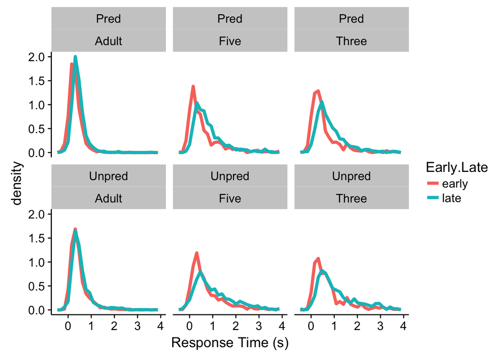

## 2.2 Analysis

An ex-gaussian distribution convolves a normal distribution with an exponential – this gives it a long and heavy right tail. We aimed to fit an ex-Gaussian to the response time data, comparing adults with children, and hierarchically modeling the mu parameter, the sigma parameter, and the tau parameter. Mu is the mean of the normal and sigma its standard deviation, while tau is the rate of the exponential. We modeled how these varied across conditions, accounting for random subjec intercepts. We print the structure of each model below.

Note that Tau is called Beta in the model, as per brms convention.

### 2.2.1 Ex-Gaussian analysis of All ages

In this analysis, we compare Adults, Five-year-olds, and Three-year-olds as separate groups.

#### 2.2.1.1 Full analysis

```r
 z <- 0
 convert_stan_to_dataframe <- function(stan_object){
   sum.df <- data.frame(summary(stan_object)$fixed)
   sum.df$Diff_from_zero <- ifelse((sum.df$l.95..CI * sum.df$u.95..CI) > 0, "*","-")
   return(sum.df)
 }


expt2.full.summary <- convert_stan_to_dataframe(expt2.model)

formula(expt2.model)
```

```
## rt ~ 1 + Age * Early.Late * Pred + (1 | Subject) + (1 | CharacterLength.ms)
## beta ~ 1 + Age * Early.Late * Pred + (1 | Subject) + (1 | CharacterLength.ms)
## sigma ~ 1 + Age * Early.Late * Pred + (1 | Subject) + (1 | CharacterLength.ms)
```

```r
kable(expt2.full.summary, digits = 2)
```

|  | Estimate | Est.Error | l.95..CI | u.95..CI | Eff.Sample | Rhat | Diff_from_zero |
| --- | --- | --- | --- | --- | --- | --- | --- |
| Intercept | 0.48 | 0.01 | 0.45 | 0.50 | 398.99 | 1.01 | * |
| sigma_Intercept | -3.29 | 0.10 | -3.49 | -3.09 | 1451.21 | 1.00 | * |
| beta_Intercept | -2.72 | 0.13 | -2.96 | -2.46 | 761.53 | 1.00 | * |
| AgeFive | -0.08 | 0.02 | -0.12 | -0.04 | 329.68 | 1.02 | * |
| AgeThree | -0.09 | 0.02 | -0.12 | -0.05 | 600.67 | 1.01 | * |
| Early.Latelate | 0.03 | 0.01 | 0.02 | 0.05 | 714.33 | 1.01 | * |
| PredUnpred | 0.03 | 0.02 | -0.01 | 0.07 | 380.39 | 1.01 | - |
| AgeFive:Early.Latelate | 0.07 | 0.01 | 0.05 | 0.09 | 1998.77 | 1.00 | * |
| AgeThree:Early.Latelate | 0.06 | 0.01 | 0.04 | 0.08 | 1932.21 | 1.00 | * |
| AgeFive:PredUnpred | 0.02 | 0.03 | -0.05 | 0.07 | 381.40 | 1.01 | - |
| AgeThree:PredUnpred | 0.01 | 0.03 | -0.05 | 0.06 | 522.02 | 1.01 | - |
| Early.Latelate:PredUnpred | -0.02 | 0.01 | -0.04 | -0.01 | 2335.89 | 1.00 | * |
| AgeFive:Early.Latelate:PredUnpred | -0.03 | 0.02 | -0.05 | 0.01 | 2389.20 | 1.00 | - |
| AgeThree:Early.Latelate:PredUnpred | 0.00 | 0.02 | -0.03 | 0.03 | 2125.51 | 1.00 | - |
| sigma_AgeFive | -0.26 | 0.20 | -0.66 | 0.12 | 1392.41 | 1.00 | - |
| sigma_AgeThree | 0.09 | 0.19 | -0.28 | 0.45 | 1777.78 | 1.00 | - |
| sigma_Early.Latelate | 0.01 | 0.09 | -0.16 | 0.19 | 2005.72 | 1.00 | - |
| sigma_PredUnpred | -0.16 | 0.15 | -0.45 | 0.13 | 1215.33 | 1.00 | - |
| sigma_AgeFive:Early.Latelate | 0.41 | 0.21 | 0.00 | 0.84 | 1908.16 | 1.00 | - |
| sigma_AgeThree:Early.Latelate | 0.21 | 0.21 | -0.20 | 0.60 | 2006.08 | 1.00 | - |
| sigma_AgeFive:PredUnpred | 0.70 | 0.26 | 0.19 | 1.21 | 1417.84 | 1.00 | * |
| sigma_AgeThree:PredUnpred | -0.30 | 0.38 | -1.12 | 0.37 | 1205.77 | 1.00 | - |
| sigma_Early.Latelate:PredUnpred | 0.10 | 0.13 | -0.15 | 0.34 | 2310.25 | 1.00 | - |
| sigma_AgeFive:Early.Latelate:PredUnpred | -0.08 | 0.27 | -0.63 | 0.44 | 1944.43 | 1.00 | - |
| sigma_AgeThree:Early.Latelate:PredUnpred | 0.30 | 0.41 | -0.43 | 1.14 | 1382.01 | 1.00 | - |
| beta_AgeFive | 1.45 | 0.17 | 1.12 | 1.79 | 700.22 | 1.00 | * |
| beta_AgeThree | 1.48 | 0.17 | 1.14 | 1.83 | 748.28 | 1.00 | * |
| beta_Early.Latelate | 0.27 | 0.08 | 0.12 | 0.41 | 1370.23 | 1.00 | * |
| beta_PredUnpred | 0.37 | 0.17 | 0.04 | 0.72 | 720.71 | 1.00 | * |
| beta_AgeFive:Early.Latelate | -0.22 | 0.09 | -0.40 | -0.03 | 1473.15 | 1.00 | * |
| beta_AgeThree:Early.Latelate | -0.13 | 0.10 | -0.33 | 0.06 | 1670.51 | 1.00 | - |
| beta_AgeFive:PredUnpred | -0.24 | 0.23 | -0.71 | 0.20 | 696.97 | 1.01 | - |
| beta_AgeThree:PredUnpred | -0.17 | 0.25 | -0.66 | 0.33 | 692.89 | 1.01 | - |
| beta_Early.Latelate:PredUnpred | -0.08 | 0.09 | -0.25 | 0.10 | 1761.82 | 1.00 | - |
| beta_AgeFive:Early.Latelate:PredUnpred | 0.28 | 0.13 | 0.04 | 0.53 | 1641.91 | 1.00 | * |
| beta_AgeThree:Early.Latelate:PredUnpred | 0.28 | 0.14 | 0.00 | 0.55 | 1924.61 | 1.00 | - |

#### 2.2.1.2 Adults alone

```r
expt2.adult.summary <- convert_stan_to_dataframe(expt2.model.adult)

formula(expt2.model.adult)
```

```
## rt ~ 1 + Early.Late * Pred + (1 | Subject) + (1 | CharacterLength.ms)
## beta ~ 1 + Early.Late * Pred + (1 | Subject) + (1 | CharacterLength.ms)
## sigma ~ 1 + Early.Late * Pred + (1 | Subject) + (1 | CharacterLength.ms)
```

```r
kable(expt2.adult.summary, digits = 2)
```

|  | Estimate | Est.Error | l.95..CI | u.95..CI | Eff.Sample | Rhat | Diff_from_zero |
| --- | --- | --- | --- | --- | --- | --- | --- |
| Intercept | 0.48 | 0.02 | 0.44 | 0.51 | 273.62 | 1.00 | * |
| sigma_Intercept | -3.26 | 0.10 | -3.47 | -3.07 | 1412.72 | 1.00 | * |
| beta_Intercept | -2.78 | 0.15 | -3.07 | -2.49 | 793.26 | 1.00 | * |
| Early.Latelate | 0.03 | 0.01 | 0.02 | 0.05 | 863.82 | 1.01 | * |
| PredUnpred | 0.03 | 0.02 | -0.01 | 0.07 | 296.23 | 1.01 | - |
| Early.Latelate:PredUnpred | -0.02 | 0.01 | -0.04 | -0.01 | 2586.51 | 1.00 | * |
| sigma_Early.Latelate | -0.01 | 0.08 | -0.17 | 0.16 | 2570.25 | 1.00 | - |
| sigma_PredUnpred | -0.17 | 0.14 | -0.45 | 0.12 | 1608.94 | 1.00 | - |
| sigma_Early.Latelate:PredUnpred | 0.16 | 0.12 | -0.07 | 0.40 | 2792.21 | 1.00 | - |
| beta_Early.Latelate | 0.28 | 0.09 | 0.10 | 0.45 | 1961.24 | 1.00 | * |
| beta_PredUnpred | 0.40 | 0.20 | -0.01 | 0.79 | 537.99 | 1.01 | - |
| beta_Early.Latelate:PredUnpred | -0.14 | 0.10 | -0.33 | 0.06 | 2342.84 | 1.00 | - |

#### 2.2.1.3 Fives alone

(divergent transitions, don’t trust this model)

```r
expt2.five.summary <- convert_stan_to_dataframe(expt2.model.five)
formula(expt2.model.five)
```

```
## rt ~ 1 + Early.Late * Pred + (1 | Subject) + (1 | CharacterLength.ms)
## beta ~ 1 + Early.Late * Pred + (1 | Subject) + (1 | CharacterLength.ms)
## sigma ~ 1 + Early.Late * Pred + (1 | Subject) + (1 | CharacterLength.ms)
```

```r
kable(expt2.five.summary, digits = 2)
```

|  | Estimate | Est.Error | l.95..CI | u.95..CI | Eff.Sample | Rhat | Diff_from_zero |
| --- | --- | --- | --- | --- | --- | --- | --- |
| Intercept | 0.40 | 0.02 | 0.36 | 0.43 | 1065.07 | 1.00 | * |
| sigma_Intercept | -3.74 | 0.24 | -4.28 | -3.33 | 1854.83 | 1.00 | * |
| beta_Intercept | -1.28 | 0.12 | -1.53 | -1.04 | 1315.85 | 1.00 | * |
| Early.Latelate | 0.12 | 0.01 | 0.10 | 0.14 | 2308.48 | 1.00 | * |
| PredUnpred | 0.04 | 0.02 | -0.01 | 0.09 | 1125.86 | 1.01 | - |
| Early.Latelate:PredUnpred | -0.04 | 0.02 | -0.07 | -0.01 | 4140.09 | 1.00 | * |
| sigma_Early.Latelate | 0.53 | 0.27 | 0.01 | 1.05 | 1698.36 | 1.00 | * |
| sigma_PredUnpred | 0.76 | 0.28 | 0.25 | 1.34 | 1995.74 | 1.00 | * |
| sigma_Early.Latelate:PredUnpred | -0.19 | 0.32 | -0.81 | 0.42 | 1965.59 | 1.00 | - |
| beta_Early.Latelate | 0.08 | 0.08 | -0.08 | 0.24 | 3468.52 | 1.00 | - |
| beta_PredUnpred | 0.13 | 0.17 | -0.20 | 0.47 | 1181.52 | 1.00 | - |
| beta_Early.Latelate:PredUnpred | 0.23 | 0.10 | 0.03 | 0.42 | 4367.18 | 1.00 | * |

#### 2.2.1.4 Threes alone

(didn’t converge, don’t trust this model)

```r
expt2.three.summary <- convert_stan_to_dataframe(expt2.model.three)
formula(expt2.model.three)
```

```
## rt ~ 1 + Early.Late * Pred + (1 | Subject) + (1 | CharacterLength.ms)
## beta ~ 1 + Early.Late * Pred + (1 | Subject) + (1 | CharacterLength.ms)
## sigma ~ 1 + Early.Late * Pred + (1 | Subject) + (1 | CharacterLength.ms)
```

```r
kable(expt2.three.summary, digits = 2)
```

|  | Estimate | Est.Error | l.95..CI | u.95..CI | Eff.Sample | Rhat | Diff_from_zero |
| --- | --- | --- | --- | --- | --- | --- | --- |
| Intercept | 0.39 | 0.01 | 0.37 | 0.41 | 58.10 | 1.06 | * |
| sigma_Intercept | -4.26 | 0.72 | -6.19 | -3.34 | 19.32 | 1.11 | * |
| beta_Intercept | -1.26 | 0.10 | -1.43 | -1.05 | 36.63 | 1.10 | * |
| Early.Latelate | 0.12 | 0.01 | 0.09 | 0.14 | 9.08 | 1.31 | * |
| PredUnpred | 0.04 | 0.02 | 0.00 | 0.07 | 33.03 | 1.09 | * |
| Early.Latelate:PredUnpred | -0.02 | 0.02 | -0.05 | 0.02 | 15.90 | 1.29 | - |
| sigma_Early.Latelate | 0.43 | 0.64 | -0.43 | 2.33 | 16.88 | 1.17 | - |
| sigma_PredUnpred | -4.86 | 2.62 | -10.07 | -0.88 | 16.12 | 1.29 | * |
| sigma_Early.Latelate:PredUnpred | 5.21 | 2.63 | 1.16 | 10.32 | 15.91 | 1.31 | * |
| beta_Early.Latelate | 0.12 | 0.07 | -0.02 | 0.28 | 63.27 | 1.04 | - |
| beta_PredUnpred | 0.25 | 0.14 | -0.02 | 0.54 | 46.58 | 1.07 | - |
| beta_Early.Latelate:PredUnpred | 0.14 | 0.13 | -0.08 | 0.37 | 10.26 | 1.22 | - |

### 2.2.2 Ex-Gaussian analysis of gross age comparisons with random slopes

#### 2.2.2.1 Adults versus children

In this analysis, we compare Adults to children.

```r
 z <- 1
 convert_stan_to_dataframe <- function(stan_object){
   sum.df <- data.frame(summary(stan_object)$fixed)
   sum.df$Diff_from_zero <- ifelse((sum.df$l.95..CI * sum.df$u.95..CI) > 0, "*","-")
   return(sum.df)
 }


expt2.model.grossage.summary <- convert_stan_to_dataframe(expt2.model.grossage)

formula(expt2.model.grossage)
```

```
## rt ~ 1 + Age * Early.Late * Pred + (1 + Early.Late | Subject) + (1 | CharacterLength.ms)
## beta ~ 1 + Age * Early.Late * Pred + (1 + Early.Late | Subject) + (1 | CharacterLength.ms)
## sigma ~ 1 + Age * Early.Late * Pred + (1 + Early.Late | Subject) + (1 | CharacterLength.ms)
```

```r
kable(expt2.model.grossage.summary, digits = 2)
```

|  | Estimate | Est.Error | l.95..CI | u.95..CI | Eff.Sample | Rhat | Diff_from_zero |
| --- | --- | --- | --- | --- | --- | --- | --- |
| Intercept | 1.05 | 0.04 | 0.97 | 1.12 | 471.04 | 1.00 | * |
| sigma_Intercept | -2.41 | 0.11 | -2.64 | -2.20 | 1337.18 | 1.00 | * |
| beta_Intercept | -1.81 | 0.13 | -2.08 | -1.55 | 764.67 | 1.00 | * |
| AgeChild | -0.22 | 0.04 | -0.30 | -0.13 | 442.58 | 1.01 | * |
| Early.Latelate | 0.08 | 0.02 | 0.04 | 0.12 | 790.64 | 1.00 | * |
| PredUnpred | 0.07 | 0.05 | -0.03 | 0.17 | 396.39 | 1.00 | - |
| AgeChild:Early.Latelate | 0.17 | 0.02 | 0.12 | 0.21 | 1617.45 | 1.00 | * |
| AgeChild:PredUnpred | 0.04 | 0.07 | -0.08 | 0.17 | 397.75 | 1.01 | - |
| Early.Latelate:PredUnpred | -0.06 | 0.02 | -0.10 | -0.02 | 1232.13 | 1.00 | * |
| AgeChild:Early.Latelate:PredUnpred | -0.03 | 0.04 | -0.10 | 0.04 | 1656.42 | 1.00 | - |
| sigma_AgeChild | -0.10 | 0.17 | -0.43 | 0.22 | 1254.83 | 1.00 | - |
| sigma_Early.Latelate | 0.05 | 0.10 | -0.15 | 0.25 | 1146.38 | 1.00 | - |
| sigma_PredUnpred | -0.12 | 0.16 | -0.43 | 0.19 | 1177.87 | 1.00 | - |
| sigma_AgeChild:Early.Latelate | 0.30 | 0.17 | -0.02 | 0.64 | 1645.61 | 1.00 | - |
| sigma_AgeChild:PredUnpred | 0.35 | 0.24 | -0.11 | 0.81 | 1215.80 | 1.00 | - |
| sigma_Early.Latelate:PredUnpred | 0.06 | 0.14 | -0.21 | 0.33 | 1724.56 | 1.00 | - |
| sigma_AgeChild:Early.Latelate:PredUnpred | 0.08 | 0.24 | -0.39 | 0.54 | 1680.38 | 1.00 | - |
| beta_AgeChild | 1.45 | 0.16 | 1.14 | 1.76 | 510.30 | 1.00 | * |
| beta_Early.Latelate | 0.28 | 0.10 | 0.10 | 0.47 | 1284.13 | 1.00 | * |
| beta_PredUnpred | 0.37 | 0.18 | 0.03 | 0.73 | 737.59 | 1.00 | * |
| beta_AgeChild:Early.Latelate | -0.17 | 0.11 | -0.38 | 0.04 | 1257.76 | 1.00 | - |
| beta_AgeChild:PredUnpred | -0.19 | 0.22 | -0.62 | 0.25 | 683.19 | 1.01 | - |
| beta_Early.Latelate:PredUnpred | -0.07 | 0.12 | -0.30 | 0.17 | 1409.65 | 1.00 | - |
| beta_AgeChild:Early.Latelate:PredUnpred | 0.25 | 0.15 | -0.04 | 0.54 | 971.40 | 1.00 | - |

#### 2.2.2.2 Adults alone

In this analysis, we analyze adults alone.

```r
 z <- 1
 convert_stan_to_dataframe <- function(stan_object){
   sum.df <- data.frame(summary(stan_object)$fixed)
   sum.df$Diff_from_zero <- ifelse((sum.df$l.95..CI * sum.df$u.95..CI) > 0, "*","-")
   return(sum.df)
 }


expt2.model.adult.noage.summary <- convert_stan_to_dataframe(expt2.model.adult.noage)

formula(expt2.model.adult.noage)
```

```
## rt ~ 1 + Early.Late * Pred + (1 + Early.Late | Subject) + (1 | CharacterLength.ms)
## beta ~ 1 + Early.Late * Pred + (1 + Early.Late | Subject) + (1 | CharacterLength.ms)
## sigma ~ 1 + Early.Late * Pred + (1 + Early.Late | Subject) + (1 | CharacterLength.ms)
```

```r
kable(expt2.model.adult.noage.summary, digits = 2)
```

|  | Estimate | Est.Error | l.95..CI | u.95..CI | Eff.Sample | Rhat | Diff_from_zero |
| --- | --- | --- | --- | --- | --- | --- | --- |
| Intercept | 1.05 | 0.05 | 0.95 | 1.13 | 432.41 | 1.01 | * |
| sigma_Intercept | -2.39 | 0.11 | -2.62 | -2.18 | 2019.10 | 1.00 | * |
| beta_Intercept | -1.87 | 0.16 | -2.19 | -1.55 | 800.22 | 1.00 | * |
| Early.Latelate | 0.08 | 0.02 | 0.04 | 0.12 | 1101.27 | 1.01 | * |
| PredUnpred | 0.07 | 0.06 | -0.04 | 0.20 | 480.10 | 1.01 | - |
| Early.Latelate:PredUnpred | -0.06 | 0.02 | -0.10 | -0.02 | 1329.26 | 1.00 | * |
| sigma_Early.Latelate | 0.02 | 0.10 | -0.17 | 0.23 | 2449.25 | 1.00 | - |
| sigma_PredUnpred | -0.13 | 0.16 | -0.44 | 0.17 | 2142.22 | 1.00 | - |
| sigma_Early.Latelate:PredUnpred | 0.14 | 0.13 | -0.13 | 0.40 | 2790.10 | 1.00 | - |
| beta_Early.Latelate | 0.29 | 0.10 | 0.10 | 0.49 | 2332.32 | 1.00 | * |
| beta_PredUnpred | 0.38 | 0.21 | -0.04 | 0.79 | 656.37 | 1.00 | - |
| beta_Early.Latelate:PredUnpred | -0.13 | 0.11 | -0.35 | 0.10 | 3143.56 | 1.00 | - |

#### 2.2.2.3 Children alone

In this analysis, we analyze children alone.

```r
 z <- 0
 convert_stan_to_dataframe <- function(stan_object){
   sum.df <- data.frame(summary(stan_object)$fixed)
   sum.df$Diff_from_zero <- ifelse((sum.df$l.95..CI * sum.df$u.95..CI) > 0, "*","-")
   return(sum.df)
 }


expt2.model.child.noage.summary <- convert_stan_to_dataframe(expt2.model.child.noage)

formula(expt2.model.child.noage)
```

```
## rt ~ 1 + Early.Late * Pred + (1 + Early.Late | Subject) + (1 | CharacterLength.ms)
## beta ~ 1 + Early.Late * Pred + (1 + Early.Late | Subject) + (1 | CharacterLength.ms)
## sigma ~ 1 + Early.Late * Pred + (1 + Early.Late | Subject) + (1 | CharacterLength.ms)
```

```r
kable(expt2.model.child.noage.summary, digits = 2)
```

|  | Estimate | Est.Error | l.95..CI | u.95..CI | Eff.Sample | Rhat | Diff_from_zero |
| --- | --- | --- | --- | --- | --- | --- | --- |
| Intercept | 0.83 | 0.03 | 0.78 | 0.89 | 634.76 | 1.01 | * |
| sigma_Intercept | -2.60 | 0.17 | -2.96 | -2.30 | 1488.74 | 1.00 | * |
| beta_Intercept | -0.34 | 0.09 | -0.52 | -0.16 | 961.51 | 1.00 | * |
| Early.Latelate | 0.31 | 0.03 | 0.26 | 0.37 | 1565.77 | 1.00 | * |
| PredUnpred | 0.10 | 0.04 | 0.03 | 0.17 | 952.79 | 1.01 | * |
| Early.Latelate:PredUnpred | -0.07 | 0.03 | -0.14 | 0.00 | 2518.40 | 1.00 | - |
| sigma_Early.Latelate | 0.26 | 0.20 | -0.11 | 0.66 | 1662.79 | 1.00 | - |
| sigma_PredUnpred | 0.24 | 0.20 | -0.15 | 0.63 | 2343.14 | 1.00 | - |
| sigma_Early.Latelate:PredUnpred | 0.25 | 0.23 | -0.20 | 0.71 | 2191.30 | 1.00 | - |
| beta_Early.Latelate | 0.10 | 0.07 | -0.05 | 0.25 | 2175.33 | 1.00 | - |
| beta_PredUnpred | 0.20 | 0.12 | -0.05 | 0.43 | 821.21 | 1.00 | - |
| beta_Early.Latelate:PredUnpred | 0.20 | 0.10 | 0.01 | 0.39 | 2291.21 | 1.00 | * |

### 2.2.3 Ex-Gaussian analysis of gross age comparisons without random slopes

#### 2.2.3.1 Adults versus children

In this analysis, we compare Adults to children.

```r
 z <- 0
 convert_stan_to_dataframe <- function(stan_object){
   sum.df <- data.frame(summary(stan_object)$fixed)
   sum.df$Diff_from_zero <- ifelse((sum.df$l.95..CI * sum.df$u.95..CI) > 0, "*","-")
   return(sum.df)
 }


expt2.model.grossage.summary <- convert_stan_to_dataframe(expt2.model.grossage)

formula(expt2.model.grossage)
```

```
## rt ~ 1 + Age * Early.Late * Pred + (1 | Subject) + (1 | CharacterLength.ms)
## beta ~ 1 + Age * Early.Late * Pred + (1 | Subject) + (1 | CharacterLength.ms)
## sigma ~ 1 + Age * Early.Late * Pred + (1 | Subject) + (1 | CharacterLength.ms)
```

```r
kable(expt2.model.grossage.summary, digits = 2)
```

|  | Estimate | Est.Error | l.95..CI | u.95..CI | Eff.Sample | Rhat | Diff_from_zero |
| --- | --- | --- | --- | --- | --- | --- | --- |
| Intercept | 2.23 | 0.04 | 2.16 | 2.30 | 237.24 | 1.01 | * |
| sigma_Intercept | -2.38 | 0.14 | -2.67 | -2.12 | 468.22 | 1.00 | * |
| beta_Intercept | -1.84 | 0.13 | -2.09 | -1.59 | 347.63 | 1.02 | * |
| AgeChild | -0.21 | 0.04 | -0.29 | -0.13 | 259.39 | 1.01 | * |
| Early.Latelate | 0.07 | 0.02 | 0.04 | 0.11 | 298.60 | 1.00 | * |
| PredUnpred | 0.07 | 0.05 | -0.02 | 0.16 | 192.38 | 1.02 | - |
| AgeChild:Early.Latelate | 0.16 | 0.02 | 0.13 | 0.20 | 1317.16 | 1.00 | * |
| AgeChild:PredUnpred | 0.05 | 0.06 | -0.07 | 0.17 | 276.20 | 1.01 | - |
| Early.Latelate:PredUnpred | -0.06 | 0.01 | -0.09 | -0.04 | 967.33 | 1.00 | * |
| AgeChild:Early.Latelate:PredUnpred | -0.03 | 0.03 | -0.08 | 0.03 | 1211.35 | 1.00 | - |
| sigma_AgeChild | 0.14 | 0.19 | -0.22 | 0.52 | 503.19 | 1.01 | - |
| sigma_Early.Latelate | -0.04 | 0.09 | -0.20 | 0.14 | 959.96 | 1.00 | - |
| sigma_PredUnpred | -0.18 | 0.20 | -0.58 | 0.21 | 509.61 | 1.00 | - |
| sigma_AgeChild:Early.Latelate | 0.12 | 0.14 | -0.17 | 0.40 | 983.68 | 1.01 | - |
| sigma_AgeChild:PredUnpred | 0.20 | 0.28 | -0.36 | 0.73 | 539.08 | 1.01 | - |
| sigma_Early.Latelate:PredUnpred | 0.10 | 0.12 | -0.14 | 0.35 | 877.56 | 1.00 | - |
| sigma_AgeChild:Early.Latelate:PredUnpred | 0.30 | 0.21 | -0.09 | 0.71 | 929.59 | 1.00 | - |
| beta_AgeChild | 1.49 | 0.15 | 1.20 | 1.78 | 347.61 | 1.02 | * |
| beta_Early.Latelate | 0.29 | 0.07 | 0.15 | 0.44 | 1093.96 | 1.00 | * |
| beta_PredUnpred | 0.42 | 0.18 | 0.07 | 0.76 | 216.79 | 1.03 | * |
| beta_AgeChild:Early.Latelate | -0.18 | 0.08 | -0.34 | -0.03 | 912.73 | 1.00 | * |
| beta_AgeChild:PredUnpred | -0.26 | 0.21 | -0.66 | 0.16 | 276.80 | 1.02 | - |
| beta_Early.Latelate:PredUnpred | -0.09 | 0.09 | -0.26 | 0.09 | 820.22 | 1.00 | - |
| beta_AgeChild:Early.Latelate:PredUnpred | 0.27 | 0.11 | 0.05 | 0.48 | 829.33 | 1.00 | * |

#### 2.2.3.2 Adults alone

In this analysis, we analyze adults alone.

```r
 z <-0
 convert_stan_to_dataframe <- function(stan_object){
   sum.df <- data.frame(summary(stan_object)$fixed)
   sum.df$Diff_from_zero <- ifelse((sum.df$l.95..CI * sum.df$u.95..CI) > 0, "*","-")
   return(sum.df)
 }


expt2.model.adult.noage.summary <- convert_stan_to_dataframe(expt2.model.adult.noage)

formula(expt2.model.adult.noage)
```

```
## rt ~ 1 + Early.Late * Pred + (1 | Subject) + (1 | CharacterLength.ms)
## beta ~ 1 + Early.Late * Pred + (1 | Subject) + (1 | CharacterLength.ms)
## sigma ~ 1 + Early.Late * Pred + (1 | Subject) + (1 | CharacterLength.ms)
```

```r
kable(expt2.model.adult.noage.summary, digits = 2)
```

|  | Estimate | Est.Error | l.95..CI | u.95..CI | Eff.Sample | Rhat | Diff_from_zero |
| --- | --- | --- | --- | --- | --- | --- | --- |
| Intercept | 2.23 | 0.04 | 2.14 | 2.31 | 224.97 | 1.01 | * |
| sigma_Intercept | -2.31 | 0.11 | -2.53 | -2.11 | 1092.69 | 1.00 | * |
| beta_Intercept | -1.89 | 0.15 | -2.17 | -1.60 | 533.69 | 1.01 | * |
| Early.Latelate | 0.08 | 0.02 | 0.04 | 0.11 | 625.56 | 1.01 | * |
| PredUnpred | 0.07 | 0.06 | -0.04 | 0.19 | 228.36 | 1.01 | - |
| Early.Latelate:PredUnpred | -0.06 | 0.01 | -0.09 | -0.04 | 2019.82 | 1.00 | * |
| sigma_Early.Latelate | -0.04 | 0.08 | -0.20 | 0.11 | 1737.34 | 1.00 | - |
| sigma_PredUnpred | -0.22 | 0.15 | -0.52 | 0.09 | 1015.35 | 1.00 | - |
| sigma_Early.Latelate:PredUnpred | 0.19 | 0.12 | -0.03 | 0.44 | 1874.22 | 1.00 | - |
| beta_Early.Latelate | 0.29 | 0.09 | 0.12 | 0.47 | 1323.09 | 1.00 | * |
| beta_PredUnpred | 0.43 | 0.20 | 0.02 | 0.82 | 485.79 | 1.01 | * |
| beta_Early.Latelate:PredUnpred | -0.15 | 0.10 | -0.34 | 0.05 | 2025.74 | 1.00 | - |

#### 2.2.3.3 Children alone

In this analysis, we analyze children alone.

```r
 z <- 1
 convert_stan_to_dataframe <- function(stan_object){
   sum.df <- data.frame(summary(stan_object)$fixed)
   sum.df$Diff_from_zero <- ifelse((sum.df$l.95..CI * sum.df$u.95..CI) > 0, "*","-")
   return(sum.df)
 }


expt2.model.child.noage.summary <- convert_stan_to_dataframe(expt2.model.child.noage)

formula(expt2.model.child.noage)
```

```
## rt ~ 1 + Early.Late * Pred + (1 | Subject) + (1 | CharacterLength.ms)
## beta ~ 1 + Early.Late * Pred + (1 | Subject) + (1 | CharacterLength.ms)
## sigma ~ 1 + Early.Late * Pred + (1 | Subject) + (1 | CharacterLength.ms)
```

```r
kable(expt2.model.child.noage.summary, digits = 2)
```

|  | Estimate | Est.Error | l.95..CI | u.95..CI | Eff.Sample | Rhat | Diff_from_zero |
| --- | --- | --- | --- | --- | --- | --- | --- |
| Intercept | 1.26 | 0.03 | 1.20 | 1.31 | 662.05 | 1.00 | * |
| sigma_Intercept | -2.44 | 0.16 | -2.80 | -2.14 | 1100.66 | 1.00 | * |
| beta_Intercept | -0.32 | 0.08 | -0.49 | -0.16 | 586.20 | 1.00 | * |
| Early.Latelate | 0.30 | 0.03 | 0.24 | 0.35 | 768.37 | 1.00 | * |
| PredUnpred | 0.11 | 0.04 | 0.04 | 0.18 | 657.39 | 1.00 | * |
| Early.Latelate:PredUnpred | -0.08 | 0.03 | -0.13 | -0.02 | 2098.62 | 1.00 | * |
| sigma_Early.Latelate | -0.07 | 0.17 | -0.42 | 0.27 | 1536.13 | 1.00 | - |
| sigma_PredUnpred | 0.16 | 0.20 | -0.22 | 0.57 | 1182.11 | 1.00 | - |
| sigma_Early.Latelate:PredUnpred | 0.38 | 0.22 | -0.07 | 0.83 | 1311.24 | 1.00 | - |
| beta_Early.Latelate | 0.10 | 0.06 | -0.02 | 0.22 | 1760.00 | 1.00 | - |
| beta_PredUnpred | 0.17 | 0.11 | -0.05 | 0.39 | 658.29 | 1.01 | - |
| beta_Early.Latelate:PredUnpred | 0.20 | 0.08 | 0.06 | 0.35 | 3200.00 | 1.00 | * |

### 2.2.4 Ex-Gaussian analysis of gross age comparisons accounting for length

#### 2.2.4.1 Adults versus children

In this analysis, we compare Adults to children.

```r
 z <- 0
 convert_stan_to_dataframe <- function(stan_object){
   sum.df <- data.frame(summary(stan_object)$fixed)
   sum.df$Diff_from_zero <- ifelse((sum.df$l.95..CI * sum.df$u.95..CI) > 0, "*","-")
   return(sum.df)
 }


expt2.model.grossage.summary <- convert_stan_to_dataframe(expt2.model.grossage.length)

formula(expt2.model.grossage.length)
```

```
## rt ~ 1 + Length + Age * Early.Late * Pred + (1 | Subject) + (1 | CharacterLength.ms)
## beta ~ 1 + Length + Age * Early.Late * Pred + (1 | Subject) + (1 | CharacterLength.ms)
## sigma ~ 1 + Length + Age * Early.Late * Pred + (1 | Subject) + (1 | CharacterLength.ms)
```

```r
kable(expt2.model.grossage.summary, digits = 2)
```

|  | Estimate | Est.Error | l.95..CI | u.95..CI | Eff.Sample | Rhat | Diff_from_zero |
| --- | --- | --- | --- | --- | --- | --- | --- |
| Intercept | 2.23 | 0.02 | 2.20 | 2.27 | 462.25 | 1.01 | * |
| sigma_Intercept | -2.28 | 0.07 | -2.42 | -2.14 | 955.28 | 1.00 | * |
| beta_Intercept | -0.84 | 0.05 | -0.95 | -0.73 | 604.45 | 1.01 | * |
| LengthShort | 0.01 | 0.01 | -0.01 | 0.03 | 405.73 | 1.01 | - |
| AgeChild | -0.06 | 0.02 | -0.09 | -0.03 | 399.76 | 1.00 | * |
| Early.Latelate | 0.06 | 0.01 | 0.04 | 0.08 | 586.03 | 1.01 | * |
| PredUnpred | 0.03 | 0.02 | 0.00 | 0.06 | 402.67 | 1.01 | * |
| AgeChild:Early.Latelate | 0.04 | 0.00 | 0.03 | 0.04 | 3200.00 | 1.00 | * |
| AgeChild:PredUnpred | 0.01 | 0.02 | -0.02 | 0.04 | 500.00 | 1.01 | - |
| Early.Latelate:PredUnpred | -0.02 | 0.00 | -0.03 | -0.01 | 3200.00 | 1.00 | * |
| AgeChild:Early.Latelate:PredUnpred | 0.00 | 0.00 | -0.01 | 0.00 | 3200.00 | 1.00 | - |
| sigma_LengthShort | -0.06 | 0.03 | -0.12 | -0.01 | 3200.00 | 1.00 | * |
| sigma_AgeChild | 0.18 | 0.07 | 0.05 | 0.31 | 846.97 | 1.00 | * |
| sigma_Early.Latelate | 0.07 | 0.03 | 0.01 | 0.14 | 2960.48 | 1.00 | * |
| sigma_PredUnpred | 0.03 | 0.06 | -0.09 | 0.16 | 1102.68 | 1.00 | - |
| sigma_AgeChild:Early.Latelate | 0.06 | 0.03 | 0.01 | 0.12 | 3200.00 | 1.00 | * |
| sigma_AgeChild:PredUnpred | 0.09 | 0.06 | -0.03 | 0.21 | 1139.00 | 1.00 | - |
| sigma_Early.Latelate:PredUnpred | 0.06 | 0.03 | 0.01 | 0.11 | 3200.00 | 1.00 | * |
| sigma_AgeChild:Early.Latelate:PredUnpred | 0.04 | 0.03 | -0.01 | 0.09 | 3200.00 | 1.00 | - |
| beta_LengthShort | 0.14 | 0.02 | 0.10 | 0.18 | 2236.93 | 1.00 | * |
| beta_AgeChild | 0.66 | 0.05 | 0.57 | 0.76 | 696.46 | 1.00 | * |
| beta_Early.Latelate | 0.11 | 0.02 | 0.07 | 0.15 | 2222.75 | 1.00 | * |
| beta_PredUnpred | 0.15 | 0.05 | 0.05 | 0.25 | 528.06 | 1.00 | * |
| beta_AgeChild:Early.Latelate | -0.01 | 0.01 | -0.04 | 0.01 | 3200.00 | 1.00 | - |
| beta_AgeChild:PredUnpred | -0.02 | 0.05 | -0.13 | 0.08 | 586.73 | 1.01 | - |
| beta_Early.Latelate:PredUnpred | 0.01 | 0.02 | -0.02 | 0.04 | 3200.00 | 1.00 | - |
| beta_AgeChild:Early.Latelate:PredUnpred | 0.03 | 0.01 | 0.01 | 0.06 | 3200.00 | 1.00 | * |

#### 2.2.4.2 Adults alone

In this analysis, we analyze adults alone.

```r
 z <-0



expt2.model.adult.noage.summary <- convert_stan_to_dataframe(expt2.model.adult.noage.length)

formula(expt2.model.adult.noage.length)
```

```
## rt ~ 1 + Length + Early.Late * Pred + (1 | Subject) + (1 | CharacterLength.ms)
## beta ~ 1 + Length + Early.Late * Pred + (1 | Subject) + (1 | CharacterLength.ms)
## sigma ~ 1 + Length + Early.Late * Pred + (1 | Subject) + (1 | CharacterLength.ms)
```

```r
kable(expt2.model.adult.noage.summary, digits = 2)
```

|  | Estimate | Est.Error | l.95..CI | u.95..CI | Eff.Sample | Rhat | Diff_from_zero |
| --- | --- | --- | --- | --- | --- | --- | --- |
| Intercept | 2.29 | 0.03 | 2.23 | 2.35 | 240.49 | 1.01 | * |
| sigma_Intercept | -2.40 | 0.07 | -2.55 | -2.26 | 942.13 | 1.00 | * |
| beta_Intercept | -1.57 | 0.10 | -1.77 | -1.35 | 421.27 | 1.01 | * |
| LengthShort | 0.01 | 0.01 | -0.01 | 0.02 | 394.92 | 1.00 | - |
| Early.Latelate | 0.02 | 0.01 | 0.01 | 0.04 | 454.86 | 1.01 | * |
| PredUnpred | 0.02 | 0.03 | -0.03 | 0.08 | 197.28 | 1.01 | - |
| Early.Latelate:PredUnpred | -0.02 | 0.00 | -0.02 | -0.01 | 3200.00 | 1.00 | * |
| sigma_LengthShort | -0.08 | 0.03 | -0.14 | -0.02 | 3200.00 | 1.00 | * |
| sigma_Early.Latelate | 0.02 | 0.03 | -0.04 | 0.09 | 2655.61 | 1.00 | - |
| sigma_PredUnpred | -0.05 | 0.07 | -0.18 | 0.08 | 1110.48 | 1.00 | - |
| sigma_Early.Latelate:PredUnpred | 0.05 | 0.03 | -0.01 | 0.11 | 3200.00 | 1.00 | - |
| beta_LengthShort | 0.15 | 0.03 | 0.09 | 0.22 | 1550.91 | 1.00 | * |
| beta_Early.Latelate | 0.11 | 0.03 | 0.05 | 0.18 | 1763.46 | 1.00 | * |
| beta_PredUnpred | 0.17 | 0.09 | -0.01 | 0.35 | 491.99 | 1.00 | - |
| beta_Early.Latelate:PredUnpred | -0.04 | 0.02 | -0.08 | 0.01 | 3200.00 | 1.00 | - |

#### 2.2.4.3 Children alone

In this analysis, we analyze children alone. Note that we had to trim RTs < -500ms for convergence.

```r
expt2.model.child.noage.summary <- convert_stan_to_dataframe(expt2.model.child.noage.length)

formula(expt2.model.child.noage.length)
```

```
## rt ~ 1 + Length + Early.Late * Pred + (1 | Subject) + (1 | CharacterLength.ms)
## beta ~ 1 + Length + Early.Late * Pred + (1 | Subject) + (1 | CharacterLength.ms)
## sigma ~ 1 + Length + Early.Late * Pred + (1 | Subject) + (1 | CharacterLength.ms)
```

```r
kable(expt2.model.child.noage.summary, digits = 2)
```

|  | Estimate | Est.Error | l.95..CI | u.95..CI | Eff.Sample | Rhat | Diff_from_zero |
| --- | --- | --- | --- | --- | --- | --- | --- |
| Intercept | 2.21 | 0.02 | 2.17 | 2.25 | 686.99 | 1.00 | * |
| sigma_Intercept | -2.23 | 0.09 | -2.43 | -2.06 | 1363.21 | 1.00 | * |
| beta_Intercept | -0.14 | 0.06 | -0.26 | -0.03 | 442.67 | 1.01 | * |
| LengthShort | 0.05 | 0.01 | 0.02 | 0.07 | 1002.92 | 1.00 | * |
| Early.Latelate | 0.13 | 0.01 | 0.11 | 0.16 | 1020.03 | 1.00 | * |
| PredUnpred | 0.03 | 0.02 | 0.00 | 0.06 | 614.94 | 1.00 | - |
| Early.Latelate:PredUnpred | -0.02 | 0.01 | -0.03 | -0.01 | 2387.45 | 1.00 | * |
| sigma_LengthShort | 0.04 | 0.06 | -0.08 | 0.15 | 2329.24 | 1.00 | - |
| sigma_Early.Latelate | 0.16 | 0.06 | 0.05 | 0.28 | 1774.10 | 1.00 | * |
| sigma_PredUnpred | 0.16 | 0.07 | 0.02 | 0.30 | 2070.72 | 1.00 | * |
| sigma_Early.Latelate:PredUnpred | 0.06 | 0.05 | -0.05 | 0.16 | 2173.95 | 1.00 | - |
| beta_LengthShort | 0.11 | 0.03 | 0.06 | 0.16 | 2082.92 | 1.00 | * |
| beta_Early.Latelate | 0.09 | 0.03 | 0.04 | 0.14 | 1976.10 | 1.00 | * |
| beta_PredUnpred | 0.14 | 0.06 | 0.03 | 0.25 | 354.05 | 1.01 | * |
| beta_Early.Latelate:PredUnpred | 0.05 | 0.02 | 0.02 | 0.09 | 3200.00 | 1.00 | * |